# Medflex GO!

Charles Marks

2/17/2019

## load the data

```r
df <- read.csv("final_dataset2019-02-12.csv", header = TRUE)
```

## compute variables and clean NAs

```r
## Current Smoker
df$current_smoker <- 0
df$current_smoker[df$smoking_status == "Current Smoker, Everyday" | df$smoking_status == "Current Smoker, Some days"] <- 1
df$current_smoker <- factor(df$current_smoker, levels = c(0,1), labels = c("No","Yes"))

## Ever Smoker
df$ever_smoker <- 0
df$ever_smoker[df$smoking_status == "Current Smoker, Everyday" | df$smoking_status == "Current Smoker, Some days" | df$smoking_status == "Former Smoker"] <- 1
df$ever_smoker <- factor(df$ever_smoker, levels = c(0,1), labels = c("No","Yes"))

## ACEs Categorical Group
df$ACE_total_cat <- 0
df$ACE_total_cat[df$ACE_total == 1] <- 1
df$ACE_total_cat[df$ACE_total == 2] <- 2
df$ACE_total_cat[df$ACE_total == 3] <- 3
df$ACE_total_cat[df$ACE_total >= 4] <- 4
df$ACE_total_cat <- factor(df$ACE_total_cat, levels = c(0,1,2,3,4), labels = c("0 ACEs","1 ACE","2 ACEs","3 ACEs","4+ ACEs"))

#note that Income has a lot of NAs so we might want to consider
#imputation or removing this variable from our analyses.
df<-na.omit(df)
```

## Mediation with Medflex

In this doc we will test for the mediating effect of tobacco use (coded dichotomously as never versus ever) on the relationship between Adverse Childhood Experiences (coded continuously as a score from 0 to 8) and three different dichotomous outcomes (history of heart disease, COPD, and cancer other than skin cancer).

This doc will be separated into three sections, one for each of the respective DVs.

## Heart Disease

### First, the Baron and Kenny Assumptions

While we are going to use natural effect models to test for mediation, it seems wise to look at the three primary relationships defined by Baron and Kenny.

- Does X predict Y?
- Does X predict M?
- Does M predict Y after controlling for X?

Here we will compute those models :

```r
heart.XY = glm(ever_heart_disease ~ ACE_total + STATE + age + race + hispanic + education + income,
                 data = df,
                 family = binomial(link="logit")
                 )

results <- exp(cbind(OR = coef(heart.XY), confint(heart.XY)))
kable(results) %>%
  kable_styling(bootstrap_options = "striped", full_width = F)
```

|  | OR | 2.5 % | 97.5 % |
| --- | --- | --- | --- |
| (Intercept) | 0.0021707 | 0.0015262 | 0.0030624 |
| ACE_total | 1.1263604 | 1.1036718 | 1.1493415 |
| STATENew York | 1.2082486 | 1.0405622 | 1.4059117 |
| STATENorth Carolina | 1.3115283 | 1.1351682 | 1.5190354 |
| STATEOklahoma | 1.5888279 | 1.3619840 | 1.8569423 |
| STATETexas | 1.3229049 | 1.1448714 | 1.5322014 |
| STATEVirginia | 1.1842347 | 1.0122739 | 1.3876062 |
| age | 1.0595254 | 1.0566939 | 1.0623936 |
| raceAsian | 0.6248908 | 0.3838365 | 0.9873690 |
| raceBlack | 0.7634826 | 0.5867075 | 1.0029728 |
| raceMultiracial | 1.3094706 | 0.9578274 | 1.7973159 |
| raceNative Hawaiian/Pacific Islander | 1.2457945 | 0.8189511 | 1.8761094 |
| raceOther | 1.0848280 | 0.7234789 | 1.6115619 |
| raceWhite | 0.8290304 | 0.6523526 | 1.0661273 |
| hispanicYes | 0.5886278 | 0.4983569 | 0.6923251 |
| educationCompleted High School | 1.3657924 | 1.2387871 | 1.5058603 |
| educationDid Not Complete High School | 1.7226270 | 1.5083293 | 1.9661111 |
| educationSome College | 1.3341827 | 1.2142177 | 1.4659737 |
| income25k-35k | 0.9679907 | 0.8588861 | 1.0902061 |
| income35k-50k | 0.8049441 | 0.7140460 | 0.9067815 |
| incomeLess than 15k | 1.4166688 | 1.2652760 | 1.5858992 |
| incomeMore than 50k | 0.7172990 | 0.6461356 | 0.7965729 |

```r
heart.XM = glm(ever_smoker ~ ACE_total + STATE + age + race + hispanic + education + income,
                 data = df,
                 family = binomial(link="logit")
                 )

results <- exp(cbind(OR = coef(heart.XM), confint(heart.XM)))
kable(results) %>%
  kable_styling(bootstrap_options = "striped", full_width = F)
```

|  | OR | 2.5 % | 97.5 % |
| --- | --- | --- | --- |
| (Intercept) | 0.2053991 | 0.1707995 | 0.2468643 |
| ACE_total | 1.2070965 | 1.1928913 | 1.2215161 |
| STATENew York | 1.1874797 | 1.0983260 | 1.2839870 |
| STATENorth Carolina | 1.2348920 | 1.1453162 | 1.3316334 |
| STATEOklahoma | 1.0887544 | 0.9993330 | 1.1862305 |
| STATETexas | 1.0265856 | 0.9510588 | 1.1082107 |
| STATEVirginia | 1.1284377 | 1.0397977 | 1.2247142 |
| age | 1.0148786 | 1.0135996 | 1.0161616 |
| raceAsian | 0.5679942 | 0.4586875 | 0.7021026 |
| raceBlack | 0.6247284 | 0.5343298 | 0.7306643 |
| raceMultiracial | 1.0722970 | 0.8810563 | 1.3053952 |
| raceNative Hawaiian/Pacific Islander | 1.0971411 | 0.8476566 | 1.4207858 |
| raceOther | 0.7407240 | 0.6017356 | 0.9110591 |
| raceWhite | 0.9990061 | 0.8649106 | 1.1544503 |
| hispanicYes | 0.4491484 | 0.4147113 | 0.4862215 |
| educationCompleted High School | 1.8084970 | 1.7118430 | 1.9106975 |
| educationDid Not Complete High School | 2.1892671 | 2.0126296 | 2.3818186 |
| educationSome College | 1.6139624 | 1.5327830 | 1.6994857 |
| income25k-35k | 1.0299745 | 0.9543163 | 1.1116236 |
| income35k-50k | 1.0098280 | 0.9394671 | 1.0854518 |
| incomeLess than 15k | 1.0745060 | 0.9956612 | 1.1596163 |
| incomeMore than 50k | 0.8537495 | 0.8028204 | 0.9079277 |

```r
heart.MY = glm(ever_heart_disease ~ ever_smoker + ACE_total + STATE + age + race + hispanic + education + income,
                 data = df,
                 family = binomial(link="logit")
                 )

results <- exp(cbind(OR = coef(heart.MY), confint(heart.MY)))
kable(results) %>%
  kable_styling(bootstrap_options = "striped", full_width = F)
```

|  | OR | 2.5 % | 97.5 % |
| --- | --- | --- | --- |
| (Intercept) | 0.0016844 | 0.0011783 | 0.0023886 |
| ever_smokerYes | 1.8070509 | 1.6826085 | 1.9412171 |
| ACE_total | 1.1014163 | 1.0789159 | 1.1242116 |
| STATENew York | 1.1865248 | 1.0213884 | 1.3812312 |
| STATENorth Carolina | 1.2928760 | 1.1186173 | 1.4979471 |
| STATEOklahoma | 1.5835410 | 1.3567993 | 1.8516198 |
| STATETexas | 1.3257811 | 1.1468055 | 1.5362480 |
| STATEVirginia | 1.1714934 | 1.0008312 | 1.3734037 |
| age | 1.0594429 | 1.0565774 | 1.0623453 |
| raceAsian | 0.6827911 | 0.4184165 | 1.0816938 |
| raceBlack | 0.7971457 | 0.6114715 | 1.0490343 |
| raceMultiracial | 1.2881662 | 0.9403841 | 1.7715679 |
| raceNative Hawaiian/Pacific Islander | 1.2311867 | 0.8077626 | 1.8579687 |
| raceOther | 1.1293255 | 0.7516406 | 1.6812604 |
| raceWhite | 0.8282221 | 0.6505880 | 1.0668499 |
| hispanicYes | 0.6616367 | 0.5600422 | 0.7784161 |
| educationCompleted High School | 1.2976945 | 1.1764102 | 1.4315148 |
| educationDid Not Complete High School | 1.5911236 | 1.3929108 | 1.8163872 |
| educationSome College | 1.2703310 | 1.1553862 | 1.3966765 |
| income25k-35k | 0.9589802 | 0.8505372 | 1.0805062 |
| income35k-50k | 0.7979234 | 0.7075355 | 0.8992299 |
| incomeLess than 15k | 1.4032333 | 1.2531062 | 1.5710715 |
| incomeMore than 50k | 0.7250983 | 0.6530416 | 0.8053770 |

In this case we see that the relationships are all significant, which suggests that mediation may exist.

### Next, We Will Test for Mediation

The method for this test was taken from this [medflex vignette](https://cran.r-project.org/web/packages/medflex/vignettes/medflex.pdf). See section 5.1 for details.

We will utilize the imputed data workflow (see Figure 3 in the vignette)

#### Step 1: neImpute()

```r
medFit <- glm(ever_heart_disease ~ ACE_total*ever_smoker + STATE + age + race + hispanic + education + income,
                 data=df,
                 family = binomial(link="logit")
                 )

expData <- neImpute(medFit)
```

#### Step 2: neModel()

```r
neMod1 <- neModel(ever_heart_disease ~ ACE_total0*ACE_total1  + STATE+age +race + hispanic+ education+ income, se = "robust",
                 family = binomial("logit"), expData = expData)
```

#### Step 3: Results

```r
summary(neMod1)
```

```
## Natural effect model
## with robust standard errors based on the sandwich estimator
## ---
## Exposure: ACE_total
## Mediator(s): ever_smoker
## ---
## Parameter estimates:
##                                         Estimate Std. Error z value
## (Intercept)                           -6.1379921  0.1750757 -35.059
## ACE_total0                             0.1050722  0.0106785   9.840
## ACE_total1                             0.0274595  0.0020892  13.143
## STATENew York                          0.1904528  0.0767560   2.481
## STATENorth Carolina                    0.2724361  0.0747659   3.644
## STATEOklahoma                          0.4646466  0.0797373   5.827
## STATETexas                             0.2821793  0.0743899   3.793
## STATEVirginia                          0.1705771  0.0809922   2.106
## age                                    0.0578099  0.0012498  46.255
## raceAsian                             -0.4680133  0.2431444  -1.925
## raceBlack                             -0.2702077  0.1400598  -1.929
## raceMultiracial                        0.2707170  0.1631721   1.659
## raceNative Hawaiian/Pacific Islander   0.2207326  0.2138385   1.032
## raceOther                              0.0833912  0.2064681   0.404
## raceWhite                             -0.1862126  0.1285092  -1.449
## hispanicYes                           -0.5292194  0.0859828  -6.155
## educationCompleted High School         0.3119178  0.0502267   6.210
## educationDid Not Complete High School  0.5433727  0.0698320   7.781
## educationSome College                  0.2879797  0.0481814   5.977
## income25k-35k                         -0.0338962  0.0617997  -0.548
## income35k-50k                         -0.2188612  0.0617822  -3.542
## incomeLess than 15k                    0.3484008  0.0597235   5.834
## incomeMore than 50k                   -0.3337743  0.0548800  -6.082
## ACE_total0:ACE_total1                 -0.0029328  0.0008082  -3.629
##                                       Pr(>|z|)
## (Intercept)                            < 2e-16 ***
## ACE_total0                             < 2e-16 ***
## ACE_total1                             < 2e-16 ***
## STATENew York                         0.013091 *
## STATENorth Carolina                   0.000269 ***
## STATEOklahoma                         5.64e-09 ***
## STATETexas                            0.000149 ***
## STATEVirginia                         0.035196 *
## age                                    < 2e-16 ***
## raceAsian                             0.054250 .
## raceBlack                             0.053702 .
## raceMultiracial                       0.097098 .
## raceNative Hawaiian/Pacific Islander  0.301960
## raceOther                             0.686291
## raceWhite                             0.147331
## hispanicYes                           7.51e-10 ***
## educationCompleted High School        5.29e-10 ***
## educationDid Not Complete High School 7.19e-15 ***
## educationSome College                 2.27e-09 ***
## income25k-35k                         0.583358
## income35k-50k                         0.000396 ***
## incomeLess than 15k                   5.43e-09 ***
## incomeMore than 50k                   1.19e-09 ***
## ACE_total0:ACE_total1                 0.000285 ***
## ---
## Signif. codes:  0 '***' 0.001 '**' 0.01 '*' 0.05 '.' 0.1 ' ' 1
```

```r
effdecomp <- neEffdecomp(neMod1)
summary(effdecomp)
```

```
## Effect decomposition on the scale of the linear predictor
## with standard errors based on the sandwich estimator
## ---
## conditional on: STATE, age, race, hispanic, education, income
## with x* = 0, x = 1
## ---
##                       Estimate Std. Error z value Pr(>|z|)
## pure direct effect    0.105072   0.010679   9.840   <2e-16 ***
## total direct effect   0.102139   0.010549   9.683   <2e-16 ***
## pure indirect effect  0.027459   0.002089  13.143   <2e-16 ***
## total indirect effect 0.024527   0.001758  13.951   <2e-16 ***
## total effect          0.129599   0.010675  12.141   <2e-16 ***
## ---
## Signif. codes:  0 '***' 0.001 '**' 0.01 '*' 0.05 '.' 0.1 ' ' 1
## (Univariate p-values reported)
```

```
## Effect decomposition on the scale of the linear predictor
## conditional on: STATE, age, race, hispanic, education, income
## with x* = 0, x = 1
```

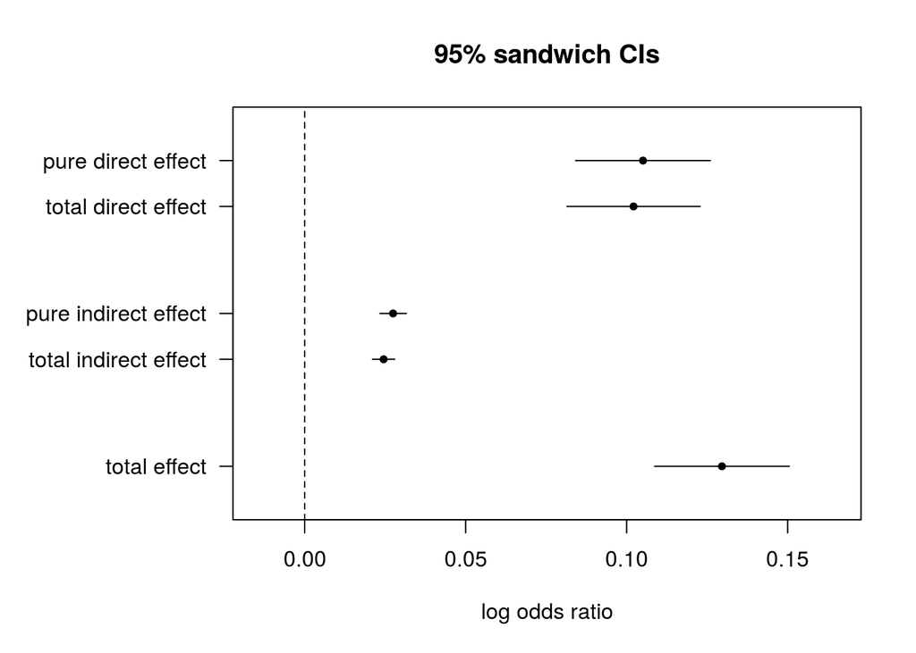

```r
plot(neMod1, xlab = "log odds ratio")
```

```
## Effect decomposition on exp(scale of the linear predictor)
## conditional on: STATE, age, race, hispanic, education, income
## with x* = 0, x = 1
```

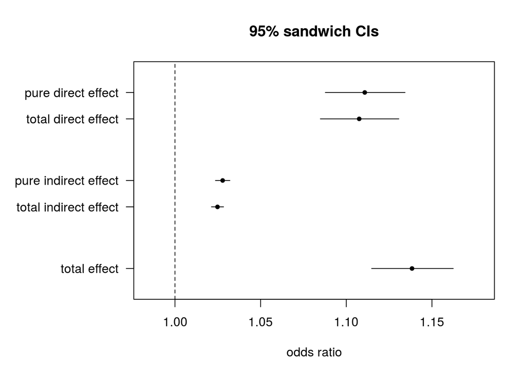

```r
plot(neMod1, xlab = "odds ratio",transf = exp)
```

## COPD

### First, the Baron and Kenny Assumptions

While we are going to use natural effect models to test for mediation, it seems wise to look at the three primary relationships defined by Baron and Kenny.

- Does X predict Y?
- Does X predict M?
- Does M predict Y after controlling for X?

Here we will compute those models :

```r
copd.XY = glm(ever_COPD ~ ACE_total + STATE + age + race + hispanic + education + income,
                 data = df,
                 family = binomial(link="logit")
                 )

results <- exp(cbind(OR = coef(copd.XY), confint(copd.XY)))
kable(results) %>%
  kable_styling(bootstrap_options = "striped", full_width = F)
```

|  | OR | 2.5 % | 97.5 % |
| --- | --- | --- | --- |
| (Intercept) | 0.0082297 | 0.0058268 | 0.0115274 |
| ACE_total | 1.2294256 | 1.2062101 | 1.2530002 |
| STATENew York | 1.2266593 | 1.0500750 | 1.4364358 |
| STATENorth Carolina | 1.2064968 | 1.0372066 | 1.4073091 |
| STATEOklahoma | 1.4067941 | 1.1956485 | 1.6585429 |
| STATETexas | 1.3847194 | 1.1891054 | 1.6166697 |
| STATEVirginia | 1.4808945 | 1.2598709 | 1.7442684 |
| age | 1.0346569 | 1.0320922 | 1.0372504 |
| raceAsian | 0.4431334 | 0.2485158 | 0.7479853 |
| raceBlack | 0.6369693 | 0.4876267 | 0.8397986 |
| raceMultiracial | 1.2094576 | 0.8818127 | 1.6647540 |
| raceNative Hawaiian/Pacific Islander | 1.3574741 | 0.8980516 | 2.0336992 |
| raceOther | 0.8290983 | 0.5368658 | 1.2605928 |
| raceWhite | 0.9802163 | 0.7706117 | 1.2619911 |
| hispanicYes | 0.4012135 | 0.3378848 | 0.4741816 |
| educationCompleted High School | 1.6025078 | 1.4434663 | 1.7798059 |
| educationDid Not Complete High School | 1.8305225 | 1.5970858 | 2.0972150 |
| educationSome College | 1.5258106 | 1.3770117 | 1.6912471 |
| income25k-35k | 0.7080018 | 0.6262086 | 0.7994825 |
| income35k-50k | 0.6371638 | 0.5653647 | 0.7173521 |
| incomeLess than 15k | 1.5683845 | 1.4119708 | 1.7420737 |
| incomeMore than 50k | 0.3625946 | 0.3249968 | 0.4044629 |

```r
copd.XM = glm(ever_smoker ~ ACE_total + STATE + age + race + hispanic + education + income,
                 data = df,
                 family = binomial(link="logit")
                 )

results <- exp(cbind(OR = coef(copd.XM), confint(copd.XM)))
kable(results) %>%
  kable_styling(bootstrap_options = "striped", full_width = F)
```

|  | OR | 2.5 % | 97.5 % |
| --- | --- | --- | --- |
| (Intercept) | 0.2053991 | 0.1707995 | 0.2468643 |
| ACE_total | 1.2070965 | 1.1928913 | 1.2215161 |
| STATENew York | 1.1874797 | 1.0983260 | 1.2839870 |
| STATENorth Carolina | 1.2348920 | 1.1453162 | 1.3316334 |
| STATEOklahoma | 1.0887544 | 0.9993330 | 1.1862305 |
| STATETexas | 1.0265856 | 0.9510588 | 1.1082107 |
| STATEVirginia | 1.1284377 | 1.0397977 | 1.2247142 |
| age | 1.0148786 | 1.0135996 | 1.0161616 |
| raceAsian | 0.5679942 | 0.4586875 | 0.7021026 |
| raceBlack | 0.6247284 | 0.5343298 | 0.7306643 |
| raceMultiracial | 1.0722970 | 0.8810563 | 1.3053952 |
| raceNative Hawaiian/Pacific Islander | 1.0971411 | 0.8476566 | 1.4207858 |
| raceOther | 0.7407240 | 0.6017356 | 0.9110591 |
| raceWhite | 0.9990061 | 0.8649106 | 1.1544503 |
| hispanicYes | 0.4491484 | 0.4147113 | 0.4862215 |
| educationCompleted High School | 1.8084970 | 1.7118430 | 1.9106975 |
| educationDid Not Complete High School | 2.1892671 | 2.0126296 | 2.3818186 |
| educationSome College | 1.6139624 | 1.5327830 | 1.6994857 |
| income25k-35k | 1.0299745 | 0.9543163 | 1.1116236 |
| income35k-50k | 1.0098280 | 0.9394671 | 1.0854518 |
| incomeLess than 15k | 1.0745060 | 0.9956612 | 1.1596163 |
| incomeMore than 50k | 0.8537495 | 0.8028204 | 0.9079277 |

```r
copd.MY = glm(ever_COPD ~ ever_smoker + ACE_total + STATE + age + race + hispanic + education + income,
                 data = df,
                 family = binomial(link="logit")
                 )

results <- exp(cbind(OR = coef(copd.MY), confint(copd.MY)))
kable(results) %>%
  kable_styling(bootstrap_options = "striped", full_width = F)
```

|  | OR | 2.5 % | 97.5 % |
| --- | --- | --- | --- |
| (Intercept) | 0.0047803 | 0.0033453 | 0.0067752 |
| ever_smokerYes | 3.1511995 | 2.9058569 | 3.4199721 |
| ACE_total | 1.1835102 | 1.1605987 | 1.2067829 |
| STATENew York | 1.1845040 | 1.0122252 | 1.3893949 |
| STATENorth Carolina | 1.1706367 | 1.0047724 | 1.3675741 |
| STATEOklahoma | 1.3943995 | 1.1828321 | 1.6470093 |
| STATETexas | 1.3857571 | 1.1878436 | 1.6207218 |
| STATEVirginia | 1.4568569 | 1.2370230 | 1.7191917 |
| age | 1.0344105 | 1.0317601 | 1.0370902 |
| raceAsian | 0.5294413 | 0.2953527 | 0.8993379 |
| raceBlack | 0.6931494 | 0.5280722 | 0.9180785 |
| raceMultiracial | 1.1834465 | 0.8580875 | 1.6378805 |
| raceNative Hawaiian/Pacific Islander | 1.3358122 | 0.8785447 | 2.0136290 |
| raceOther | 0.8953835 | 0.5766307 | 1.3693518 |
| raceWhite | 0.9754825 | 0.7634091 | 1.2611980 |
| hispanicYes | 0.5078553 | 0.4272978 | 0.6008439 |
| educationCompleted High School | 1.4353460 | 1.2911240 | 1.5962751 |
| educationDid Not Complete High School | 1.5594695 | 1.3590219 | 1.7887213 |
| educationSome College | 1.3846563 | 1.2478320 | 1.5369426 |
| income25k-35k | 0.6953592 | 0.6139931 | 0.7865479 |
| income35k-50k | 0.6277787 | 0.5561761 | 0.7078919 |
| incomeLess than 15k | 1.5528776 | 1.3957484 | 1.7276545 |
| incomeMore than 50k | 0.3697203 | 0.3310715 | 0.4127983 |

In this case we see that the relationships are all significant, which suggests that mediation may exist.

### Next, We Will Test for Mediation

The method for this test was taken from this [medflex vignette](https://cran.r-project.org/web/packages/medflex/vignettes/medflex.pdf). See section 5.1 for details.

We will utilize the imputed data workflow (see Figure 3 in the vignette)

#### Step 1: neImpute()

```r
medFit <- glm(ever_COPD ~ ACE_total*ever_smoker + STATE + age + race + hispanic + education + income,
                 data=df,
                 family = binomial(link="logit")
                 )

expData <- neImpute(medFit)
```

#### Step 2: neModel()

```r
neMod1 <- neModel(ever_COPD ~ ACE_total0*ACE_total1  + STATE+age +race + hispanic+ education+ income, se = "robust",
                 family = binomial("logit"), expData = expData)
```

#### Step 3: Results

```r
summary(neMod1)
```

```
## Natural effect model
## with robust standard errors based on the sandwich estimator
## ---
## Exposure: ACE_total
## Mediator(s): ever_smoker
## ---
## Parameter estimates:
##                                         Estimate Std. Error z value
## (Intercept)                           -4.8124722  0.1714474 -28.070
## ACE_total0                             0.1719550  0.0098226  17.506
## ACE_total1                             0.0483833  0.0024545  19.712
## STATENew York                          0.2013191  0.0802637   2.508
## STATENorth Carolina                    0.1868886  0.0782894   2.387
## STATEOklahoma                          0.3406043  0.0839893   4.055
## STATETexas                             0.3249845  0.0779283   4.170
## STATEVirginia                          0.3913025  0.0837064   4.675
## age                                    0.0341120  0.0011570  29.483
## raceAsian                             -0.8127332  0.2801666  -2.901
## raceBlack                             -0.4490119  0.1391189  -3.228
## raceMultiracial                        0.1932369  0.1624448   1.190
## raceNative Hawaiian/Pacific Islander   0.3033649  0.2132322   1.423
## raceOther                             -0.1860541  0.2199045  -0.846
## raceWhite                             -0.0182004  0.1254297  -0.145
## hispanicYes                           -0.9176237  0.0912284 -10.059
## educationCompleted High School         0.4723877  0.0549662   8.594
## educationDid Not Complete High School  0.6075445  0.0717211   8.471
## educationSome College                  0.4231545  0.0531566   7.961
## income25k-35k                         -0.3436905  0.0625720  -5.493
## income35k-50k                         -0.4489677  0.0609677  -7.364
## incomeLess than 15k                    0.4512201  0.0543241   8.306
## incomeMore than 50k                   -1.0123609  0.0576506 -17.560
## ACE_total0:ACE_total1                 -0.0026957  0.0006885  -3.915
##                                       Pr(>|z|)
## (Intercept)                            < 2e-16 ***
## ACE_total0                             < 2e-16 ***
## ACE_total1                             < 2e-16 ***
## STATENew York                          0.01213 *
## STATENorth Carolina                    0.01698 *
## STATEOklahoma                         5.01e-05 ***
## STATETexas                            3.04e-05 ***
## STATEVirginia                         2.94e-06 ***
## age                                    < 2e-16 ***
## raceAsian                              0.00372 **
## raceBlack                              0.00125 **
## raceMultiracial                        0.23422
## raceNative Hawaiian/Pacific Islander   0.15482
## raceOther                              0.39751
## raceWhite                              0.88463
## hispanicYes                            < 2e-16 ***
## educationCompleted High School         < 2e-16 ***
## educationDid Not Complete High School  < 2e-16 ***
## educationSome College                 1.71e-15 ***
## income25k-35k                         3.96e-08 ***
## income35k-50k                         1.78e-13 ***
## incomeLess than 15k                    < 2e-16 ***
## incomeMore than 50k                    < 2e-16 ***
## ACE_total0:ACE_total1                 9.04e-05 ***
## ---
## Signif. codes:  0 '***' 0.001 '**' 0.01 '*' 0.05 '.' 0.1 ' ' 1
```

```r
effdecomp <- neEffdecomp(neMod1)
summary(effdecomp)
```

```
## Effect decomposition on the scale of the linear predictor
## with standard errors based on the sandwich estimator
## ---
## conditional on: STATE, age, race, hispanic, education, income
## with x* = 0, x = 1
## ---
##                       Estimate Std. Error z value Pr(>|z|)
## pure direct effect    0.171955   0.009823   17.51   <2e-16 ***
## total direct effect   0.169259   0.009716   17.42   <2e-16 ***
## pure indirect effect  0.048383   0.002455   19.71   <2e-16 ***
## total indirect effect 0.045688   0.002193   20.84   <2e-16 ***
## total effect          0.217643   0.009977   21.81   <2e-16 ***
## ---
## Signif. codes:  0 '***' 0.001 '**' 0.01 '*' 0.05 '.' 0.1 ' ' 1
## (Univariate p-values reported)
```

```
## Effect decomposition on the scale of the linear predictor
## conditional on: STATE, age, race, hispanic, education, income
## with x* = 0, x = 1
```

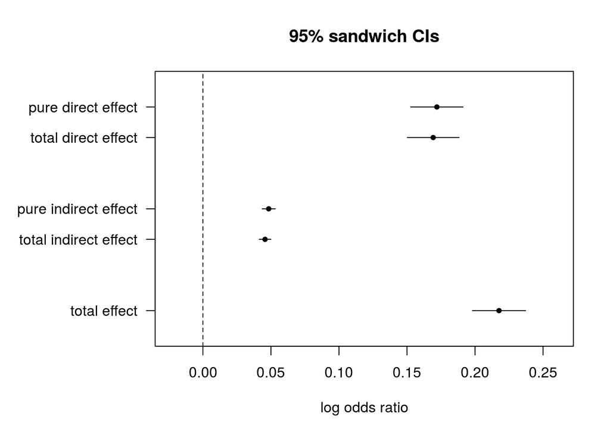

```r
plot(neMod1, xlab = "log odds ratio")
```

```
## Effect decomposition on exp(scale of the linear predictor)
## conditional on: STATE, age, race, hispanic, education, income
## with x* = 0, x = 1
```

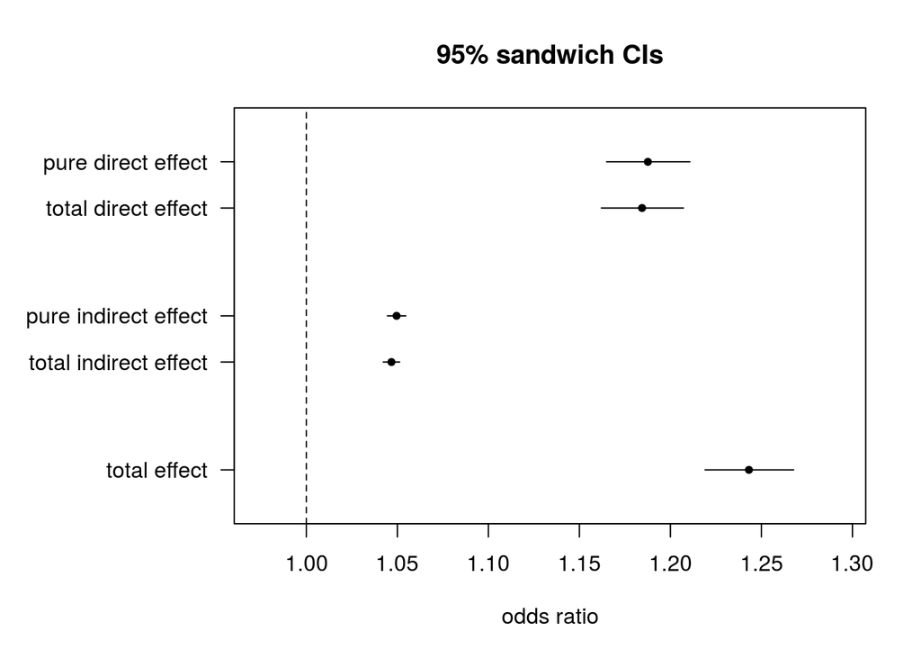

```r
plot(neMod1, xlab = "odds ratio",transf = exp)
```

## Cancer

### First, the Baron and Kenny Assumptions

While we are going to use natural effect models to test for mediation, it seems wise to look at the three primary relationships defined by Baron and Kenny.

- Does X predict Y?
- Does X predict M?
- Does M predict Y after controlling for X?

Here we will compute those models :

```r
cancer.XY = glm(ever_cancer_except_skin_cancer ~ ACE_total + STATE + age + race + hispanic + education + income,
                 data = df,
                 family = binomial(link="logit")
                 )

results <- exp(cbind(OR = coef(cancer.XY), confint(cancer.XY)))
kable(results) %>%
  kable_styling(bootstrap_options = "striped", full_width = F)
```

|  | OR | 2.5 % | 97.5 % |
| --- | --- | --- | --- |
| (Intercept) | 0.0042192 | 0.0029501 | 0.0059689 |
| ACE_total | 1.1049650 | 1.0828127 | 1.1273774 |
| STATENew York | 0.8916137 | 0.7804378 | 1.0197870 |
| STATENorth Carolina | 0.9297318 | 0.8165619 | 1.0600595 |
| STATEOklahoma | 0.7978195 | 0.6884304 | 0.9248556 |
| STATETexas | 0.9328312 | 0.8194284 | 1.0632829 |
| STATEVirginia | 1.0053079 | 0.8763991 | 1.1542373 |
| age | 1.0555274 | 1.0528093 | 1.0582786 |
| raceAsian | 0.4648752 | 0.2853657 | 0.7385251 |
| raceBlack | 0.6990929 | 0.5259664 | 0.9414457 |
| raceMultiracial | 0.8680393 | 0.6069315 | 1.2440109 |
| raceNative Hawaiian/Pacific Islander | 1.0961188 | 0.6910098 | 1.7126546 |
| raceOther | 0.7434263 | 0.4598835 | 1.1763154 |
| raceWhite | 0.9299582 | 0.7180297 | 1.2242274 |
| hispanicYes | 0.5900199 | 0.4973649 | 0.6963269 |
| educationCompleted High School | 0.8788950 | 0.7997525 | 0.9654941 |
| educationDid Not Complete High School | 0.8826541 | 0.7638739 | 1.0179540 |
| educationSome College | 1.0360133 | 0.9502248 | 1.1292621 |
| income25k-35k | 1.1197449 | 0.9887137 | 1.2675025 |
| income35k-50k | 1.0564692 | 0.9369187 | 1.1910282 |
| incomeLess than 15k | 1.1771104 | 1.0356445 | 1.3370573 |
| incomeMore than 50k | 0.9981917 | 0.8988411 | 1.1093800 |

```r
cancer.XM = glm(ever_smoker ~ ACE_total + STATE + age + race + hispanic + education + income,
                 data = df,
                 family = binomial(link="logit")
                 )

results <- exp(cbind(OR = coef(cancer.XM), confint(cancer.XM)))
kable(results) %>%
  kable_styling(bootstrap_options = "striped", full_width = F)
```

|  | OR | 2.5 % | 97.5 % |
| --- | --- | --- | --- |
| (Intercept) | 0.2053991 | 0.1707995 | 0.2468643 |
| ACE_total | 1.2070965 | 1.1928913 | 1.2215161 |
| STATENew York | 1.1874797 | 1.0983260 | 1.2839870 |
| STATENorth Carolina | 1.2348920 | 1.1453162 | 1.3316334 |
| STATEOklahoma | 1.0887544 | 0.9993330 | 1.1862305 |
| STATETexas | 1.0265856 | 0.9510588 | 1.1082107 |
| STATEVirginia | 1.1284377 | 1.0397977 | 1.2247142 |
| age | 1.0148786 | 1.0135996 | 1.0161616 |
| raceAsian | 0.5679942 | 0.4586875 | 0.7021026 |
| raceBlack | 0.6247284 | 0.5343298 | 0.7306643 |
| raceMultiracial | 1.0722970 | 0.8810563 | 1.3053952 |
| raceNative Hawaiian/Pacific Islander | 1.0971411 | 0.8476566 | 1.4207858 |
| raceOther | 0.7407240 | 0.6017356 | 0.9110591 |
| raceWhite | 0.9990061 | 0.8649106 | 1.1544503 |
| hispanicYes | 0.4491484 | 0.4147113 | 0.4862215 |
| educationCompleted High School | 1.8084970 | 1.7118430 | 1.9106975 |
| educationDid Not Complete High School | 2.1892671 | 2.0126296 | 2.3818186 |
| educationSome College | 1.6139624 | 1.5327830 | 1.6994857 |
| income25k-35k | 1.0299745 | 0.9543163 | 1.1116236 |
| income35k-50k | 1.0098280 | 0.9394671 | 1.0854518 |
| incomeLess than 15k | 1.0745060 | 0.9956612 | 1.1596163 |
| incomeMore than 50k | 0.8537495 | 0.8028204 | 0.9079277 |

```r
cancer.MY = glm(ever_cancer_except_skin_cancer ~ ever_smoker + ACE_total + STATE + age + race + hispanic + education + income,
                 data = df,
                 family = binomial(link="logit")
                 )

results <- exp(cbind(OR = coef(cancer.MY), confint(cancer.MY)))
kable(results) %>%
  kable_styling(bootstrap_options = "striped", full_width = F)
```

|  | OR | 2.5 % | 97.5 % |
| --- | --- | --- | --- |
| (Intercept) | 0.0040194 | 0.0028077 | 0.0056916 |
| ever_smokerYes | 1.1950569 | 1.1162655 | 1.2794578 |
| ACE_total | 1.0970813 | 1.0748699 | 1.1195602 |
| STATENew York | 0.8862428 | 0.7756987 | 1.0136902 |
| STATENorth Carolina | 0.9241712 | 0.8116497 | 1.0537536 |
| STATEOklahoma | 0.7963912 | 0.6871841 | 0.9232174 |
| STATETexas | 0.9331298 | 0.8196579 | 1.0636642 |
| STATEVirginia | 1.0017333 | 0.8732292 | 1.1501998 |
| age | 1.0552127 | 1.0524876 | 1.0579707 |
| raceAsian | 0.4758333 | 0.2920305 | 0.7561167 |
| raceBlack | 0.7085631 | 0.5330204 | 0.9543193 |
| raceMultiracial | 0.8628822 | 0.6032873 | 1.2367029 |
| raceNative Hawaiian/Pacific Islander | 1.0891747 | 0.6864718 | 1.7022134 |
| raceOther | 0.7504033 | 0.4641438 | 1.1875242 |
| raceWhite | 0.9293156 | 0.7174753 | 1.2234743 |
| hispanicYes | 0.6084046 | 0.5127457 | 0.7182014 |
| educationCompleted High School | 0.8641946 | 0.7862141 | 0.9495433 |
| educationDid Not Complete High School | 0.8603841 | 0.7445303 | 0.9923816 |
| educationSome College | 1.0192808 | 0.9346296 | 1.1113175 |
| income25k-35k | 1.1163556 | 0.9857319 | 1.2636500 |
| income35k-50k | 1.0536195 | 0.9344064 | 1.1877943 |
| incomeLess than 15k | 1.1727794 | 1.0319378 | 1.3320035 |
| incomeMore than 50k | 1.0019503 | 0.9022803 | 1.1134870 |

In this case we see that the relationships are all significant, which suggests that mediation may exist.

### Next, We Will Test for Mediation

The method for this test was taken from this [medflex vignette](https://cran.r-project.org/web/packages/medflex/vignettes/medflex.pdf). See section 5.1 for details.

We will utilize the imputed data workflow (see Figure 3 in the vignette)

#### Step 1: neImpute()

```r
medFit <- glm(ever_cancer_except_skin_cancer ~ ACE_total*ever_smoker + STATE + age + race + hispanic + education + income,
                 data=df,
                 family = binomial(link="logit")
                 )

expData <- neImpute(medFit)
```

#### Step 2: neModel()

```r
neMod1 <- neModel(ever_cancer_except_skin_cancer ~ ACE_total0*ACE_total1  + STATE+age +race + hispanic+ education+ income, se = "robust",
                 family = binomial("logit"), expData = expData)
```

#### Step 3: Results

```r
summary(neMod1)
```

```
## Natural effect model
## with robust standard errors based on the sandwich estimator
## ---
## Exposure: ACE_total
## Mediator(s): ever_smoker
## ---
## Parameter estimates:
##                                         Estimate Std. Error z value
## (Intercept)                           -5.4687118  0.1777232 -30.771
## ACE_total0                             0.0953328  0.0105896   9.002
## ACE_total1                             0.0083664  0.0017704   4.726
## STATENew York                         -0.1141791  0.0682667  -1.673
## STATENorth Carolina                   -0.0723770  0.0664755  -1.089
## STATEOklahoma                         -0.2252423  0.0757874  -2.972
## STATETexas                            -0.0687694  0.0666710  -1.031
## STATEVirginia                          0.0058301  0.0703390   0.083
## age                                    0.0540226  0.0012547  43.057
## raceAsian                             -0.7656722  0.2414190  -3.172
## raceBlack                             -0.3583999  0.1492402  -2.401
## raceMultiracial                       -0.1411517  0.1841481  -0.767
## raceNative Hawaiian/Pacific Islander   0.0921235  0.2359191   0.390
## raceOther                             -0.2963434  0.2440120  -1.214
## raceWhite                             -0.0724515  0.1366536  -0.530
## hispanicYes                           -0.5275263  0.0884992  -5.961
## educationCompleted High School        -0.1290114  0.0488794  -2.639
## educationDid Not Complete High School -0.1249529  0.0749302  -1.668
## educationSome College                  0.0353346  0.0441759   0.800
## income25k-35k                          0.1127806  0.0640788   1.760
## income35k-50k                          0.0544473  0.0619139   0.879
## incomeLess than 15k                    0.1630892  0.0665999   2.449
## incomeMore than 50k                   -0.0022444  0.0552109  -0.041
## ACE_total0:ACE_total1                 -0.0007920  0.0007742  -1.023
##                                       Pr(>|z|)
## (Intercept)                            < 2e-16 ***
## ACE_total0                             < 2e-16 ***
## ACE_total1                            2.29e-06 ***
## STATENew York                          0.09442 .
## STATENorth Carolina                    0.27625
## STATEOklahoma                          0.00296 **
## STATETexas                             0.30232
## STATEVirginia                          0.93394
## age                                    < 2e-16 ***
## raceAsian                              0.00152 **
## raceBlack                              0.01633 *
## raceMultiracial                        0.44337
## raceNative Hawaiian/Pacific Islander   0.69618
## raceOther                              0.22457
## raceWhite                              0.59598
## hispanicYes                           2.51e-09 ***
## educationCompleted High School         0.00831 **
## educationDid Not Complete High School  0.09540 .
## educationSome College                  0.42379
## income25k-35k                          0.07840 .
## income35k-50k                          0.37918
## incomeLess than 15k                    0.01433 *
## incomeMore than 50k                    0.96757
## ACE_total0:ACE_total1                  0.30631
## ---
## Signif. codes:  0 '***' 0.001 '**' 0.01 '*' 0.05 '.' 0.1 ' ' 1
```

```r
effdecomp <- neEffdecomp(neMod1)
summary(effdecomp)
```

```
## Effect decomposition on the scale of the linear predictor
## with standard errors based on the sandwich estimator
## ---
## conditional on: STATE, age, race, hispanic, education, income
## with x* = 0, x = 1
## ---
##                       Estimate Std. Error z value Pr(>|z|)
## pure direct effect    0.095333   0.010590   9.002  < 2e-16 ***
## total direct effect   0.094541   0.010450   9.047  < 2e-16 ***
## pure indirect effect  0.008366   0.001770   4.726 2.29e-06 ***
## total indirect effect 0.007574   0.001481   5.114 3.15e-07 ***
## total effect          0.102907   0.010530   9.773  < 2e-16 ***
## ---
## Signif. codes:  0 '***' 0.001 '**' 0.01 '*' 0.05 '.' 0.1 ' ' 1
## (Univariate p-values reported)
```

```
## Effect decomposition on the scale of the linear predictor
## conditional on: STATE, age, race, hispanic, education, income
## with x* = 0, x = 1
```

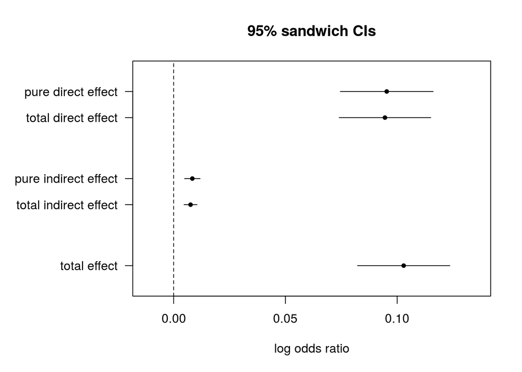

```r
plot(neMod1, xlab = "log odds ratio")
```

```
## Effect decomposition on exp(scale of the linear predictor)
## conditional on: STATE, age, race, hispanic, education, income
## with x* = 0, x = 1
```

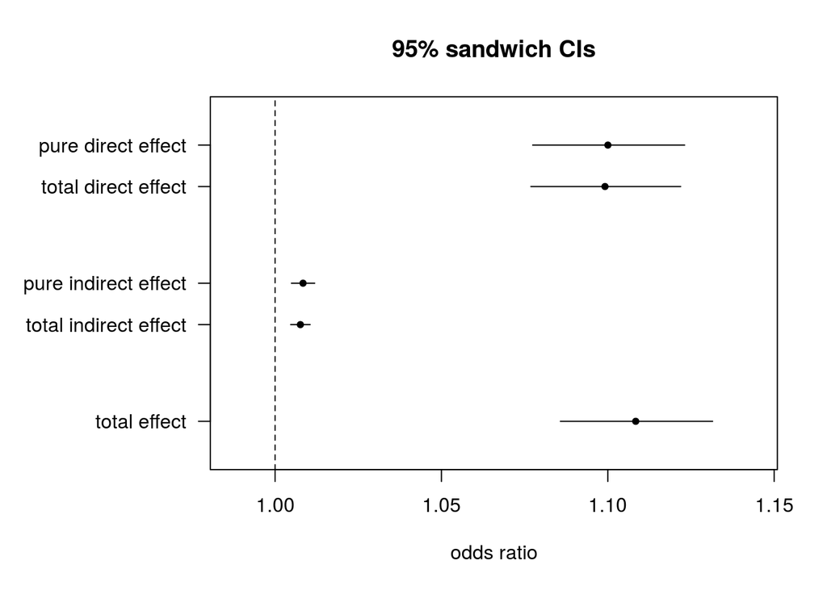

```r
plot(neMod1, xlab = "odds ratio",transf = exp)
```